# Practice Session I

My e-mail: sophie.nottmeyer@cemfi.edu.es

## 1. JupyterLab

### Introduction

*Jupyter* = open-source software project developping services for interactive computing across different programming languages (core: **Ju**lia, **Py**thon, **R**)

*Jupyter Notebook* = web-based application you can run on your browser to create "notebooks" - single files that contain everything you need in a data workflow (more on this later)

[*JupyterLab*](https://jupyterlab.readthedocs.io/en/stable/) (what we are using here) = evolution of Jupyter Notebook

### Set-up

Please make sure you have followed the [installation instructions](https://gdsl-ul.github.io/soft_install/https://gdsl-ul.github.io/soft_install/).

If, for whatever reason, you did not manage to install everything or something is not working during the class, you can use [Binder](https://darribas.org/gds4ae/content/pages/infrastructure.html) to follow the lecture. Note that there is no way to save any changes you make to your local machine using this platform.

For this course, we are using a virtual container on **Docker**. Basically, what that means is that you don't need to install Python or any libraries on your local machine. It ensures that everyone can run the code in the same environment.

To run Python on JupyterLab through Docker, follow these steps:

1. Copy the following command in your Terminal (for Mac) or PowerShell (for Windows):

`docker run --rm -ti -p 8888:8888 -v ${PWD}:/home/jovyan/work darribas/gds:6.1`

1. Open `localhost:8888` in your browser and paste the token shown in the output text of the terminal.

Don't close either docker nor the terminal while your session is running. If you do, it will automatically expire, kernels are shut down and all unsaved changes will be lost.

### JupyterLab Interface Tour

The JupyterLab Interface provides flexible building blocks for interactive computing.

The main interface includes a main work area, a side bar on the left and a menu bar up top.

[figure not shown]

#### Main work area

This is where different kinds of documents and files are displayed in tabs (default) or panels. On start-up, you always see the **launcher tab** where you can select the type of file you want to create, depending on the number of kernels installed.

> Kernel = separate process that runs your code in different programming languages

You can always open a new launcher tab by clicking `File>New Launcher` in the menu bar or the blue "+" button top left.

These are the formats you can open from the launcher:

- **Notebook**: main document we will be working with (more on this later)
- **Console**: allows to run code interactively, execute commands with `Shift + Enter`
- **Terminal**:
  - provides full support of system shells/PowerShell
  - runs on same system as Jupyter server (here: virtual container)
  - type `pip list` to see packages installed
  - install and update other packages as needed
- Text editor
- Markdown file
- **Contextual help**
  - does not show anything when launched but whenever you type or double click on an object or command in the notebook, it will interactively show you the description or help file, respectively
  - another way to directly display the documentation is adding a `?` behind a command

In the main work area you can also open any kind of media (e.g. images, pdf, html, tex) and raw data files in CSV format.

Importantly, you can customize your workspace in any way you want: every tab can be rearranged and resized. Just **drag and drop** tabs to split windows in different ways.

You can also simultaneously view the same file or even just the output of a single cell in an extra window if you want to keep it for reference by right clicking on the tab or cell in question and open `New View`.

#### Side panel

Can be toggled off if you need more space by just clicking on the active tab.

As you can see there are several tabs:

- **File Browser**
  - browse and open files
  - files you create always shop up in the current folder you are in, which is then set as the working directory of that file
  - type `%pwd` to see what directory you are in
  - `\home\jovyan` is a workspace that only exists within the docker image
  - always save your files inside the `work` directory
  - if you have created a notebook outside and later put it in aother folder, you can adjust the directory by typing `%cd "/home/jovyan/work/<your path on local machine>` (see top line in launcher)
- Running Terminals and Kernels: check running sessions
- Table of Contents: shows markdown structure of notebooks
- Extension Manager

#### Menu bar

Top level menu with several options

- `File` : create, save and export files
  - notebooks can be converted to a number of open standard output formats (e.g. HTML, LaTeX, PDF) through `Export Notebook As`
- `Kernel`: restart kernel if necessary
- `Settings`: change keystroke to execute commands, font size etc.

### Jupyter Notebooks

Main vehicle we will use to communicate content of the course and create code. Documents that combine live runnable code with narrative text and rich output (e.g. interactive visualizations).

> Notebooks have a ".ipynb" extension.

Notebooks are structured as an ordered list of **cells**, which keep your data, thoughts and code in little containers.

A few tips on how to handle, create and manipulate cells, including the most important **keyboard short-cuts**:

- active/selected cells have a blue bar next to them
- switch from Edit Mode to Command Mode by pressing `Esc`
- switch from Command Mode to Edit Mode by pressing `Enter`
- use arrow keys to navigate in Command Mode
- `b` create below, `a` create above
- `c` copy, `v` paste, `x` cut
- `dd` (pressing d twice) delete
- `z` undo, `Shift + z` redo
- `m` change cell type to Markdown, `y` change to code
- run cells by hitting `Control + Enter` or `Shift + Enter`
- select multiple cells with `Shift + J`

There are two types of cells: Code and Markdown.

#### Code cells

The language used for code is that of the kernel: Python 3. When running a code cell, JupyterLab takes the code, sends it to the Pytho interpreter, who is sending back the result and prints the **output** directly below the cell.

The square brackets next to the cell, e.g. `[1]`, indicates the **execution order** of your code.

> The notebook is running on the same kernel, so whatever you code in a single cell is true for the whole notebook *according to this order*.

You can collapse the output by clickin on the blue bar next to it. `Shift + L` toggles code line numbers within cells.

#### Markdown cells

When running a Markdown cell, the text will be rendered as stylized text using standard Markdown syntax. This is a really easy way to format text.

Basic syntax (more [here](https://www.markdownguide.org/basic-syntax/)):

- titles and subtitles with `#`
- bold `** text **`, italic `* text*`
- ordered list using `1.`, `2.`, `3.` etc.
- unordered lists using `-`
- horizontal rule `---`
- `inline code`
- equations using latex syntax `$ math $`, e.g. $x^2$
- add `\` to avoid formatting

#### Save and Close

You can save your notebook with `Control + S`. This will save code and output but if you shut down the kernel anything you create on-the-fly (e.g. defining variables) will not be readily available if you open the notebook again, unless you run the respective cells.

## 2. Python Programming Essentials

We are now ready to start learning the Python language itself.

### Basic Syntax

```python
# comments start with #
x = 'hola mundo' # use '' or "" for strings
print(x)
```

```
hola mundo
```

#### Primitive Data Types

Variables in Python don't need to be declared, just used for the first time, and can change their type when overwritten.

```python
x = 3
print(type(x))
y = 2.5
print(type(y))
v = 100 < 10
print(type(v))
v
```

```
<class 'int'>
<class 'float'>
<class 'bool'>
```

```
False
```

```python
v1 = False
v2 = True
v1 + v2 # boolean arithmetic
```

```
1
```

#### Containers

Collection of objects

##### Lists and Tuples

```python
ϵ = [] # creates an empty list, type \epsilon + tab to automatically get mathematical symbol
ϵ
```

```
[]
```

```python
x = [10,'foo',False] # can combine different data types
type(x)
```

```
list
```

```python
x.append(2.5) # adding a value to a list
x
```

```
[10, 'foo', False, 2.5]
```

> Note: Lists in Python are **zero-based**, so the first element is referenced by `x[0]`

```python
x[0]
```

```
10
```

Lists are "mutable" which means they can still be altered after creation

```python
y = [1,2]
y[0] = 10 # assigning new value using index
y
```

```
[10, 2]
```

Tuples are "immutable" lists, i.e. the object cannot be changed.

```python
y = (1,2)
y[0] = 10
```

```
---------------------------------------------------------------------------
TypeError                                 Traceback (most recent call last)
<ipython-input-9-ab2994abb2bc> in <module>
      1 y = (1,2)
----> 2 y[0] = 10

TypeError: 'tuple' object does not support item assignment
```

Both lists and tuples can be "unpacked"

```python
integers = (10, 20, 30)
x, y, z = integers
y
```

```
20
```

To access multiple elements of a list or tuple, you can use Python's **slice notation**.

```python
a = [2, 4, 6, 8]
a[1:3]
```

```
[4, 6]
```

> Note: the general rule is that `a[m:n]` returns `n-m` elements, starting at `a[m]`

```python
a[1:]
```

```
[4, 6, 8]
```

```python
a[-2:] # last two elements
```

```
[6, 8]
```

```python
s = 'cemfi'
s[-2:] # also works on strings
```

```
'fi'
```

##### Sets and Dictionaries

```python
d = {'name':'Frodo','age':33} # dictionaries are like lists but named instead of numbered
type(d)
```

```
dict
```

```python
d
```

```
{'name': 'Frodo', 'age': 33}
```

```python
d['age']
```

```
33
```

The names `'name'` and `'age'` are *keys* and the objects that they are mapped to are *values*.

Sets are unordered collections without duplicates.

```python
s1 = {'a','b'}
type(s1)
```

```
set
```

```python
s2 = {'b','c'}
s1.intersection(s2)
```

```
{'b'}
```

> Note: you can look at all the variables you created by right-clicking somewhere in the notebook and selecting `Open Variable Inspector`

#### Iterating

You can iterate over many kinds of objects using the `for` loop.

> Note: Python knows the extent of the code block *only from indentation*

Importantly, you can loop without explicit indexing. For example:

```python
x_values = [1, 2, 3]
for x in x_values: # note syntax
    print(x*x)
```

```
1
4
9
```

Instead of:

```python
for i in range(len(x_values)):
    print(x_values[i]*x_values[i])
```

```
1
4
9
```

Here is an example of looping over non-numerical objects:

```python
animals = ['dog','cat','bird']
for animal in animals:
    print("The plural of " + animal + " is " + animal + "s")
```

```
The plural of dog is dogs
The plural of cat is cats
The plural of bird is birds
```

You could do the same thing using the "list comprehension" tool of Python

```python
plurals = [animal + 's' for animal in animals]
plurals
```

```
['dogs', 'cats', 'birds']
```

`zip()` allows you to step through pairs from two sequences:

```python
countries = ('Japan','Korea','China')
cities = ('Tokyo','Seoul','Beijing')
for country, city in zip(countries,cities):
    print(f'The capital of {country} is {city}')
```

```
The capital of Japan is Tokyo
The capital of Korea is Seoul
The capital of China is Beijing
```

If you actually need the index from a list, one option is to use `enumerate()`

```python
letter_list = ['a','b','c']
for index, letter in enumerate(letter_list):
    print(f"letter_list[{index}]='{letter}'")
```

```
letter_list[0]='a'
letter_list[1]='b'
letter_list[2]='c'
```

#### Comparisons and Logical Operators

```python
x, y = 1, 2
x < y
```

```
True
```

```python
x = 1 # Assignment
x == 2 # Comparison
```

```
False
```

```python
1 != 2
```

```
True
```

```python
1 < 2 and 'g' in 'foo'
```

```
False
```

```python
numbers = [-9, 2.3, -11, 0]

for x in numbers:
    if x < 0:
        print(-1)
    else:
        print(1)
```

```
-1
1
-1
1
```

#### Functions

```python
def f(x):
    if x < 0:
        return 'negative'
    return 'nonnegative'
f(5)
```

```
'nonnegative'
```

```python
def f(x, a=1, b=1):
    return a + b * x
f(2)
```

```
3
```

```python
f(2, a=4, b=5)
```

```
14
```

### Scientific Libraries

The core language of Python is rather small. You almost always need to import additional functionality in the form of scientific libraries, i.e. collections of efficient code that implement certain routines.

In terms of popularity, the big four Python libraries are:

1. **NumPy**: provides basic array data types such as vectors and matrices plus core array operations & basic numerical programming (e.g. random number generator, common mathematical functions)
2. **SciPy**: adds other kinds of numerical methods that are routinely used (e.g. interpolation, optimization)
3. **Matplotlib**: for generating figures, with a focus on plotting data stored in NumPy arrays
4. **Pandas**: provides data types and functions for empirical work (e.g. manipulating data), fast and efficient data analysis tool

Use `import` to load any packages in the first lines of your program and access functionalities afterwards via the syntax `packagename.attribute`. Example:

```python
import numpy as np  # imports package as 'np' (shorter)
np.sqrt(4)
```

```
2.0
```

Another way to access NumPy's square root function directly is

```python
from numpy import sqrt
sqrt(4)
```

```
2.0
```

### Introduction to Data Management with Pandas

This section borrows parts from the corresponding [Chapter](https://python-programming.quantecon.org/pandas/html) of the [QuantEcon Python Programming for Economics and Finance course](https://python-programaming.quantecon.org/intro.html) by Thomas J. Sargent and John Stachurski. The [pandas documentation](https://pandas.pydata.org/docs/index.html) is also a great resource for this part.

```python
import pandas as pd
import numpy as np
import matplotlib.pyplot as plt # importing a sub-routine
plt.rcParams["figure.figsize"]=[10,8] # Set default figure size
```

Two important data types defined by pandas are `Series` and `DataFrame`.

You can think of a Series as a "column" of data, such as a collection of observations for a single variable. A DataFrame is an object for storing multiple *related* columns of data.

#### Series

Imagine four listed companies with the values being daily returns on their shares:

```python
s = pd.Series(np.random.randn(4), name='daily returns')
s
```

```
0   -0.649309
1    1.227159
2    0.854529
3   -0.684808
Name: daily returns, dtype: float64
```

Pandas `Series` are built on top of NumPy arrays and support many similar operations. For example:

```python
s * 100
```

```
0    -64.930855
1    122.715888
2     85.452902
3    -68.480798
Name: daily returns, dtype: float64
```

```python
np.abs(s)
```

```
0    0.649309
1    1.227159
2    0.854529
3    0.684808
Name: daily returns, dtype: float64
```

`Series` however provides some additional (statistically oriented) methods:

```python
s.describe()
```

```
count    4.000000
mean     0.186893
std      0.997829
min     -0.684808
25%     -0.658183
50%      0.102610
75%      0.947686
max      1.227159
Name: daily returns, dtype: float64
```

```python
s.index = ['AMZN','APPL','MSFT','GOOG'] # flexible indices
s
```

```
AMZN   -0.649309
APPL    1.227159
MSFT    0.854529
GOOG   -0.684808
Name: daily returns, dtype: float64
```

```python
s['AMZN'] # show indexed value
```

```
-0.6493085454000093
```

```python
s['AMZN'] = 0 # edit individual values
s
```

```
AMZN    0.000000
APPL    1.227159
MSFT    0.854529
GOOG   -0.684808
Name: daily returns, dtype: float64
```

```python
'APPL' in s
```

```
True
```

#### DataFrames

A `DataFrame` contains several columns, one for each variable. For example:

```python
df = pd.DataFrame({'categorical': pd.Categorical(['d','e','f']),
                   'numeric': [1,2,3],
                   'object':['a','b','c']
                    })
df
```

|  | categorical | numeric | object |
| --- | --- | --- | --- |
| 0 | d | 1 | a |
| 1 | e | 2 | b |
| 2 | f | 3 | c |

```python
df.describe() # by default only numeric fields are returned
```

|  | numeric |
| --- | --- |
| count | 3.0 |
| mean | 2.0 |
| std | 1.0 |
| min | 1.0 |
| 25% | 1.5 |
| 50% | 2.0 |
| 75% | 2.5 |
| max | 3.0 |

```python
df.describe(include='all')
```

|  | categorical | numeric | object |
| --- | --- | --- | --- |
| count | 3 | 3.0 | 3 |
| unique | 3 | NaN | 3 |
| top | d | NaN | b |
| freq | 1 | NaN | 1 |
| mean | NaN | 2.0 | NaN |
| std | NaN | 1.0 | NaN |
| min | NaN | 1.0 | NaN |
| 25% | NaN | 1.5 | NaN |
| 50% | NaN | 2.0 | NaN |
| 75% | NaN | 2.5 | NaN |
| max | NaN | 3.0 | NaN |

Now let's assume we have a CSV file with data stored on our computer that we want to work with. You can read it in using the `pandas` function `read_csv`.

```python
df = pd.read_csv('./data/test_pwt.csv') # make sure path is set correctly
```

If you want to directly access a file from a website you can use the same code with the URL in brackets. If you want to read in data contained in a Stata `.dta` file to dataframes, use pandas' `.read_stata()` routine.

There is also a library called [pandas_datareader](https://pandas-datareader.readthedocs.io/en/latest) that gives you access to many data sources (e.g. from the World Bank) straight from the Jupyter notebook.

> Tip: Raw data in CSV format can always be viewed by double-clicking on the file in the browser.

```python
df # display data
```

|  | country | country isocode | year | POP | XRAT | tcgdp | cc | cg |
| --- | --- | --- | --- | --- | --- | --- | --- | --- |
| 0 | Argentina | ARG | 2000 | 37335.653 | 0.999500 | 2.950722e+05 | 75.716805 | 5.578804 |
| 1 | Australia | AUS | 2000 | 19053.186 | 1.724830 | 5.418047e+05 | 67.759026 | 6.720098 |
| 2 | India | IND | 2000 | 1006300.297 | 44.941600 | 1.728144e+06 | 64.575551 | 14.072206 |
| 3 | Israel | ISR | 2000 | 6114.570 | 4.077330 | 1.292539e+05 | 64.436451 | 10.266688 |
| 4 | Malawi | MWI | 2000 | 11801.505 | 59.543808 | 5.026222e+03 | 74.707624 | 11.658954 |
| 5 | South Africa | ZAF | 2000 | 45064.098 | 6.939830 | 2.272424e+05 | 72.718710 | 5.726546 |
| 6 | United States | USA | 2000 | 282171.957 | 1.000000 | 9.898700e+06 | 72.347054 | 6.032454 |
| 7 | Uruguay | URY | 2000 | 3219.793 | 12.099592 | 2.525596e+04 | 78.978740 | 5.108068 |

```python
type(df) # check type of object at hand
```

```
pandas.core.frame.DataFrame
```

```python
df.head() # useful method to investigate data frame
```

|  | country | country isocode | year | POP | XRAT | tcgdp | cc | cg |
| --- | --- | --- | --- | --- | --- | --- | --- | --- |
| 0 | Argentina | ARG | 2000 | 37335.653 | 0.999500 | 2.950722e+05 | 75.716805 | 5.578804 |
| 1 | Australia | AUS | 2000 | 19053.186 | 1.724830 | 5.418047e+05 | 67.759026 | 6.720098 |
| 2 | India | IND | 2000 | 1006300.297 | 44.941600 | 1.728144e+06 | 64.575551 | 14.072206 |
| 3 | Israel | ISR | 2000 | 6114.570 | 4.077330 | 1.292539e+05 | 64.436451 | 10.266688 |
| 4 | Malawi | MWI | 2000 | 11801.505 | 59.543808 | 5.026222e+03 | 74.707624 | 11.658954 |

```python
len(df) # number of rows/obs
```

```
8
```

```python
df.info()
```

```
<class 'pandas.core.frame.DataFrame'>
RangeIndex: 8 entries, 0 to 7
Data columns (total 8 columns):
 #   Column           Non-Null Count  Dtype
---  ------           --------------  -----
 0   country          8 non-null      object
 1   country isocode  8 non-null      object
 2   year             8 non-null      int64
 3   POP              8 non-null      float64
 4   XRAT             8 non-null      float64
 5   tcgdp            8 non-null      float64
 6   cc               8 non-null      float64
 7   cg               8 non-null      float64
dtypes: float64(5), int64(1), object(2)
memory usage: 640.0+ bytes
```

Missing values are usually represented in the form of NaN or null or None in the dataset.

```python
print(df.isnull().sum()) #check if there are null values
```

```
country            0
country isocode    0
year               0
POP                0
XRAT               0
tcgdp              0
cc                 0
cg                 0
dtype: int64
```

```python
df[2:5] # select particular rows
```

|  | country | country isocode | year | POP | XRAT | tcgdp | cc | cg |
| --- | --- | --- | --- | --- | --- | --- | --- | --- |
| 2 | India | IND | 2000 | 1006300.297 | 44.941600 | 1.728144e+06 | 64.575551 | 14.072206 |
| 3 | Israel | ISR | 2000 | 6114.570 | 4.077330 | 1.292539e+05 | 64.436451 | 10.266688 |
| 4 | Malawi | MWI | 2000 | 11801.505 | 59.543808 | 5.026222e+03 | 74.707624 | 11.658954 |

```python
df[['country','tcgdp']] # select particular columns
```

|  | country | tcgdp |
| --- | --- | --- |
| 0 | Argentina | 2.950722e+05 |
| 1 | Australia | 5.418047e+05 |
| 2 | India | 1.728144e+06 |
| 3 | Israel | 1.292539e+05 |
| 4 | Malawi | 5.026222e+03 |
| 5 | South Africa | 2.272424e+05 |
| 6 | United States | 9.898700e+06 |
| 7 | Uruguay | 2.525596e+04 |

To select both rows and columns using integers, you can use the `iloc` attribute with the syntax `.iloc[rows,columns]`

```python
df.iloc[2:5,0:4]
```

|  | country | country isocode | year | POP |
| --- | --- | --- | --- | --- |
| 2 | India | IND | 2000 | 1006300.297 |
| 3 | Israel | ISR | 2000 | 6114.570 |
| 4 | Malawi | MWI | 2000 | 11801.505 |

To select rows and columns using both integers and labers, use the `loc` attribute

```python
df.loc[df.index[2:5],['country','tcgdp']]
```

|  | country | tcgdp |
| --- | --- | --- |
| 2 | India | 1.728144e+06 |
| 3 | Israel | 1.292539e+05 |
| 4 | Malawi | 5.026222e+03 |

```python
df.loc[3] # use single label returns series
```

```
country                  Israel
country isocode             ISR
year                       2000
POP                     6114.57
XRAT                    4.07733
tcgdp              129253.89423
cc                    64.436451
cg                    10.266688
Name: 3, dtype: object
```

```python
subset = df.country.str.contains('t') # extract indeces of all countries containing a 't' in their name
subset
```

```
0     True
1     True
2    False
3    False
4    False
5     True
6     True
7    False
Name: country, dtype: bool
```

```python
df.loc[subset].head()
```

|  | country | country isocode | year | POP | XRAT | tcgdp | cc | cg |
| --- | --- | --- | --- | --- | --- | --- | --- | --- |
| 0 | Argentina | ARG | 2000 | 37335.653 | 0.99950 | 2.950722e+05 | 75.716805 | 5.578804 |
| 1 | Australia | AUS | 2000 | 19053.186 | 1.72483 | 5.418047e+05 | 67.759026 | 6.720098 |
| 5 | South Africa | ZAF | 2000 | 45064.098 | 6.93983 | 2.272424e+05 | 72.718710 | 5.726546 |
| 6 | United States | USA | 2000 | 282171.957 | 1.00000 | 9.898700e+06 | 72.347054 | 6.032454 |

```python
print(len(df.country[subset])) # how many are there?
```

```
4
```

If you are only interested in a sub-set of variables, you can strip the data frame down to only those variables by overwriting it using the selection methods described above:

```python
df = df[['country','POP','tcgdp']]
df
```

|  | country | POP | tcgdp |
| --- | --- | --- | --- |
| 0 | Argentina | 37335.653 | 2.950722e+05 |
| 1 | Australia | 19053.186 | 5.418047e+05 |
| 2 | India | 1006300.297 | 1.728144e+06 |
| 3 | Israel | 6114.570 | 1.292539e+05 |
| 4 | Malawi | 11801.505 | 5.026222e+03 |
| 5 | South Africa | 45064.098 | 2.272424e+05 |
| 6 | United States | 282171.957 | 9.898700e+06 |
| 7 | Uruguay | 3219.793 | 2.525596e+04 |

```python
df = df.set_index('country') # set index to be country because it is redundant
df
```

| country | POP | tcgdp |
| --- | --- | --- |
| Argentina | 37335.653 | 2.950722e+05 |
| Australia | 19053.186 | 5.418047e+05 |
| India | 1006300.297 | 1.728144e+06 |
| Israel | 6114.570 | 1.292539e+05 |
| Malawi | 11801.505 | 5.026222e+03 |
| South Africa | 45064.098 | 2.272424e+05 |
| United States | 282171.957 | 9.898700e+06 |
| Uruguay | 3219.793 | 2.525596e+04 |

```python
df.columns = 'population', 'total GDP' # rename columns
df
```

| country | population | total GDP |
| --- | --- | --- |
| Argentina | 37335.653 | 2.950722e+05 |
| Australia | 19053.186 | 5.418047e+05 |
| India | 1006300.297 | 1.728144e+06 |
| Israel | 6114.570 | 1.292539e+05 |
| Malawi | 11801.505 | 5.026222e+03 |
| South Africa | 45064.098 | 2.272424e+05 |
| United States | 282171.957 | 9.898700e+06 |
| Uruguay | 3219.793 | 2.525596e+04 |

```python
df['population'] = df['population'] * 1e3 # convert population from thousands to single units
df
```

| country | population | total GDP |
| --- | --- | --- |
| Argentina | 3.733565e+07 | 2.950722e+05 |
| Australia | 1.905319e+07 | 5.418047e+05 |
| India | 1.006300e+09 | 1.728144e+06 |
| Israel | 6.114570e+06 | 1.292539e+05 |
| Malawi | 1.180150e+07 | 5.026222e+03 |
| South Africa | 4.506410e+07 | 2.272424e+05 |
| United States | 2.821720e+08 | 9.898700e+06 |
| Uruguay | 3.219793e+06 | 2.525596e+04 |

```python
df['GDP percap'] = df['total GDP'] * 1e6 / df['population'] # adding a column showing real GDP per capita, obtained by the other two columns
df
```

| country | population | total GDP | GDP percap |
| --- | --- | --- | --- |
| Argentina | 3.733565e+07 | 2.950722e+05 | 7903.229085 |
| Australia | 1.905319e+07 | 5.418047e+05 | 28436.433261 |
| India | 1.006300e+09 | 1.728144e+06 | 1717.324719 |
| Israel | 6.114570e+06 | 1.292539e+05 | 21138.672749 |
| Malawi | 1.180150e+07 | 5.026222e+03 | 425.896679 |
| South Africa | 4.506410e+07 | 2.272424e+05 | 5042.647686 |
| United States | 2.821720e+08 | 9.898700e+06 | 35080.381854 |
| Uruguay | 3.219793e+06 | 2.525596e+04 | 7843.970620 |

```python
df.describe()
```

|  | population | total GDP | GDP percap |
| --- | --- | --- | --- |
| count | 8.000000e+00 | 8.000000e+00 | 8.000000 |
| mean | 1.763826e+08 | 1.606312e+06 | 13448.569581 |
| std | 3.479223e+08 | 3.397025e+06 | 13047.950117 |
| min | 3.219793e+06 | 5.026222e+03 | 425.896679 |
| 25% | 1.037977e+07 | 1.032544e+05 | 4211.316944 |
| 50% | 2.819442e+07 | 2.611573e+05 | 7873.599852 |
| 75% | 1.043411e+08 | 8.383896e+05 | 22963.112877 |
| max | 1.006300e+09 | 9.898700e+06 | 35080.381854 |

#### Plotting

Data objects in `pandas` have methods for plotting and visualization that work through `matplotlib`. For example:

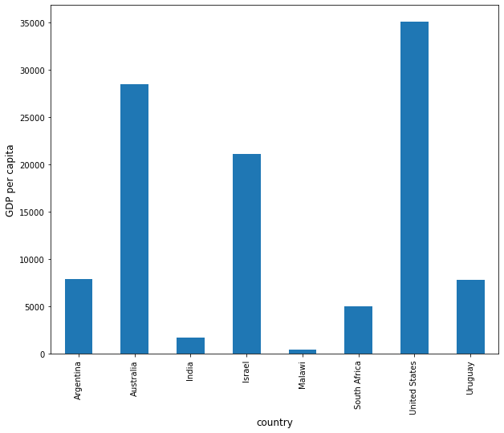

```python
ax = df['GDP percap'].plot(kind='bar')
ax.set_xlabel('country', fontsize=12)
ax.set_ylabel('GDP per capita', fontsize=12)
plt.show() # remember we called the `pyplot` routine of matplotlib "plt"
```

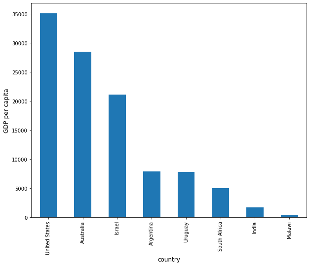

```python
df = df.sort_values(by='GDP percap', ascending=False) # change order of data frame from alphabetically to GDP per capita

ax = df['GDP percap'].plot(kind='bar')
ax.set_xlabel('country', fontsize=12)
ax.set_ylabel('GDP per capita', fontsize=12)
plt.show()
```